fossil

# Foot-and-mouth transmission trees, dug back up.

Morelli MJ, Thebaud G, Chadoeuf J, King DP, Haydon DT, Soubeyrand S. A Bayesian inference framework to reconstruct transmission trees using epidemiological and genetic data. PLoS Comput Biol 8(11):e1002768 (2012). [doi:10.1371/journal.pcbi.1002768](https://doi.org/10.1371/journal.pcbi.1002768). CC BY 2.5.

## Install transtree

Python package

```
pip install "git+https://github.com/jeonglab-bcm/fossil#subdirectory=PMC3499255/package"
```

[README](https://github.com/jeonglab-bcm/fossil/blob/main/PMC3499255/package/README.md) [Tutorial](https://github.com/jeonglab-bcm/fossil/blob/main/PMC3499255/package/tutorial/TUTORIAL.md)

### Fig. 1 (dynamical model schematic)

not attempted

A diagram of the transmission dynamics between two premises; nothing to recompute.

### Fig. 5 (model DAG schematic)

not attempted

The directed acyclic graph of the model; nothing to recompute.

### Pseudo-likelihood divergence traversal vs the Fig. S1 worked example

agrees

divergence traversal matches all 6 pairs of the Fig. S1 example

### Fig. 2 (simulated 20-premise outbreak)

agrees

Published

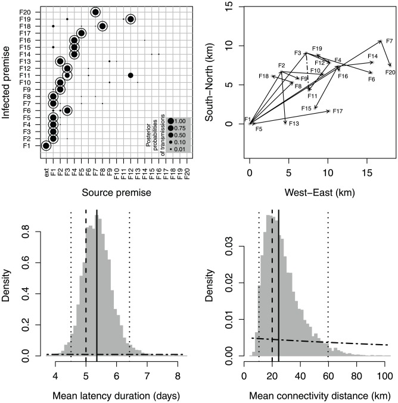

Reproduced

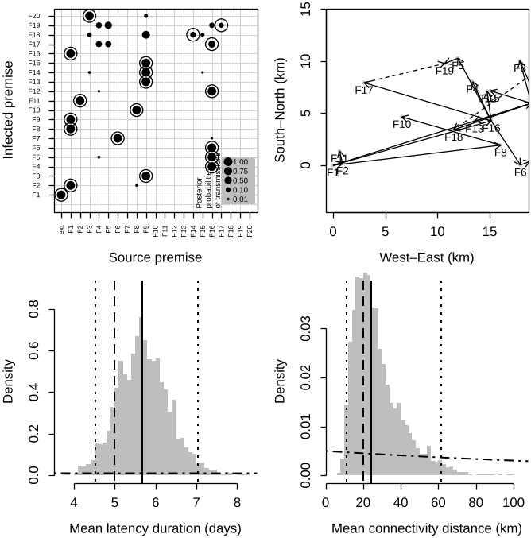

| Quantity | Paper | Reproduced |
| --- | --- | --- |
| true mean latency in 95% interval | yes | yes |
| true mean distance in 95% interval | yes | yes |
| correctly reconstructed transmissions (of 20) | 19 | 18 |

The paper deposited no seed and no data for the simulated test outbreak, so this is a fresh realization of the same model, not the same dataset. The specific map and dot pattern therefore differ by construction; the panels are drawn on the published pixel grid and histogram axes for comparison. What the paper reports for Fig. 2 reproduces: the tree misses at most a couple of the 20 transmissions, and the true mean latency and mean transmission distance fall inside the 95% intervals.

agrees

MCMC traces and running medians

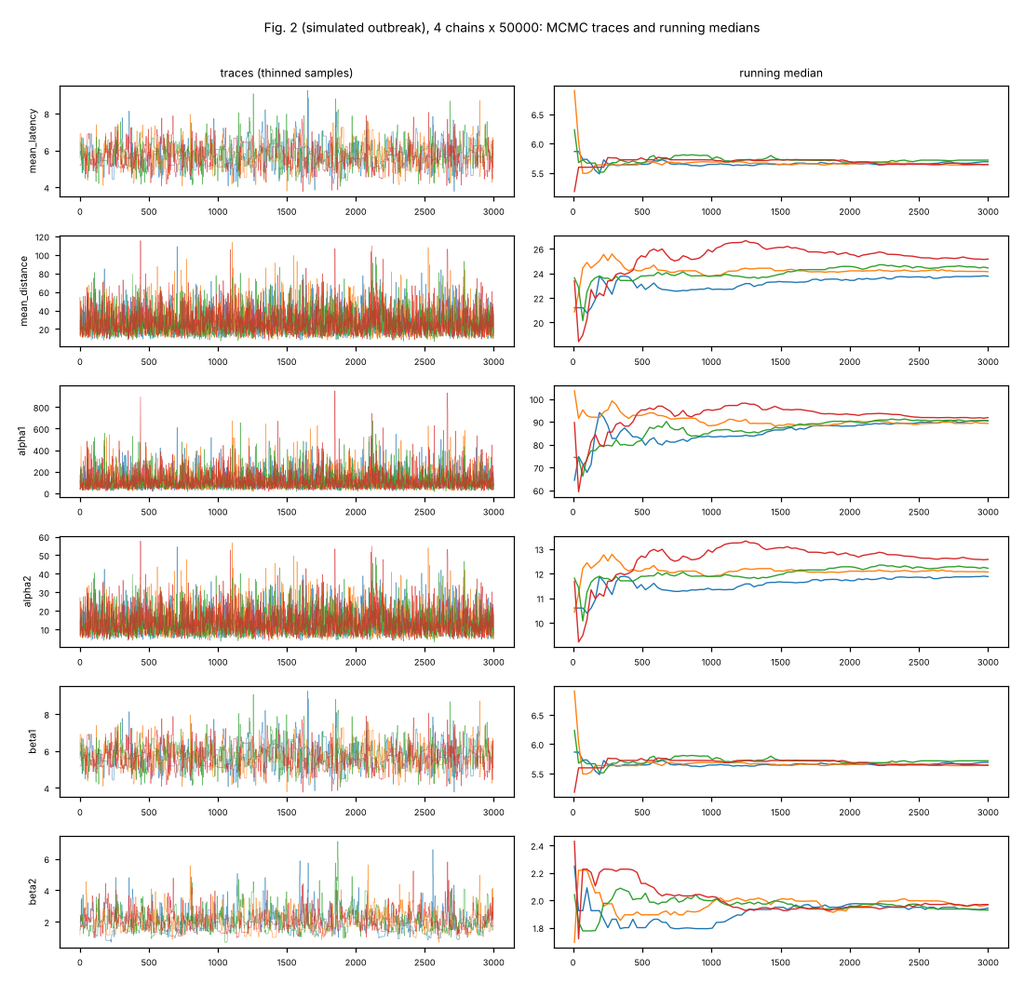

4 chains x 50000: max R-hat 1.004, min ESS 671, most-likely-source agreement 1.0, max transmission-prob diff 0.062

### Fig. 3 (2007 UK outbreak)

agrees

Published

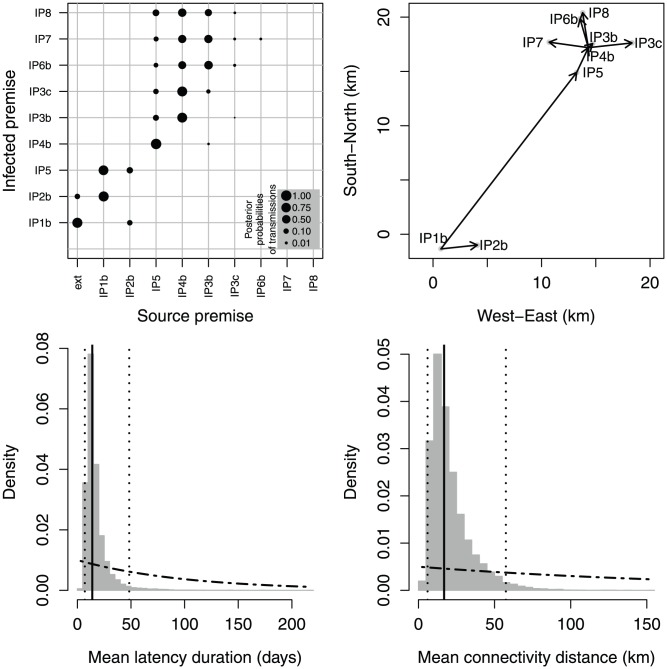

Reproduced

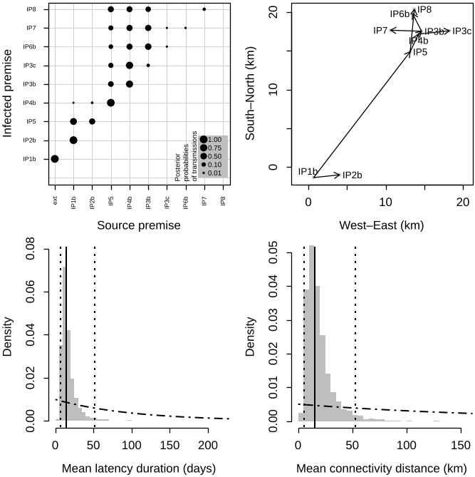

| Quantity | Paper | Reproduced |
| --- | --- | --- |
| mean latency median (days) | 14 | 14.3782 |
| mean latency 95% lo | 6 | 6.9462 |
| mean latency 95% hi | 49 | 51.3234 |
| mean transmission distance median (km) | 17 | 15.5529 |
| mean transmission distance 95% lo | 5 | 5.7413 |
| mean transmission distance 95% hi | 58 | 52.6754 |
| IP5 infected from phase 1 (prob) | 1.00 | 1.00 |

The highest-posterior tree reproduces the paper's two-phase scenario (IP1b to IP2b and IP5, IP5 to IP4b, IP4b to the rest), and IP5 links the two phases with posterior probability 1. Medians and intervals agree within Monte Carlo error.

### Fig. 3 convergence (4 chains x 100k)

agrees

MCMC traces and running medians

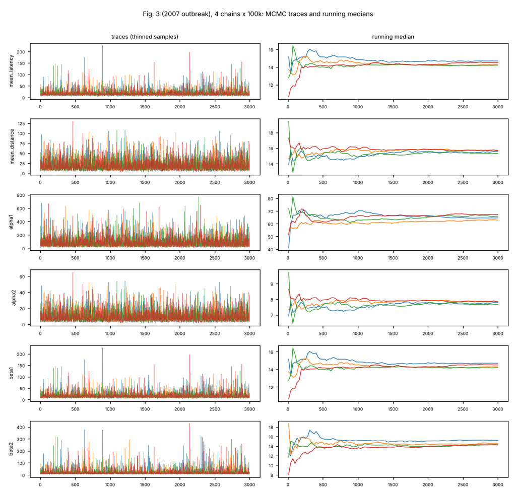

4 chains x 100000: max R-hat 1.002, min ESS 3673, most-likely-source agreement 0.944, max transmission-prob diff 0.032

Four independent chains of 100,000 iterations each (400,000 total, within a factor of the paper's 500,000) converge: R-hat below 1.01 on every continuous parameter, effective sample sizes in the thousands, and the chains agree on the most-likely source of almost every premise. The reported medians, intervals and figure are pooled over the four chains.

### Fig. 4 (2001 Darlington cluster)

partly

Published

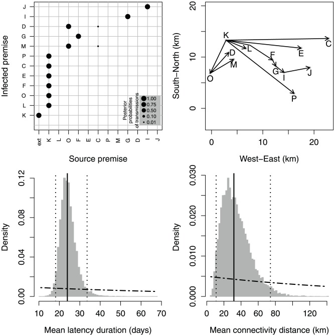

Reproduced

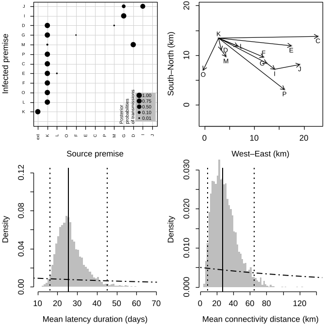

| Quantity | Paper | Reproduced |
| --- | --- | --- |
| mean latency median (days) | 24 | 25.6936 |
| mean latency 95% lo | 17 | 16.3044 |
| mean latency 95% hi | 35 | 45.1318 |
| K is the hub (max out-degree premise) | yes | yes |
| most likely scenario posterior probability | 0.99 | 0.7318 |

### Fig. 4 convergence (4 chains x 100k)

agrees

MCMC traces and running medians

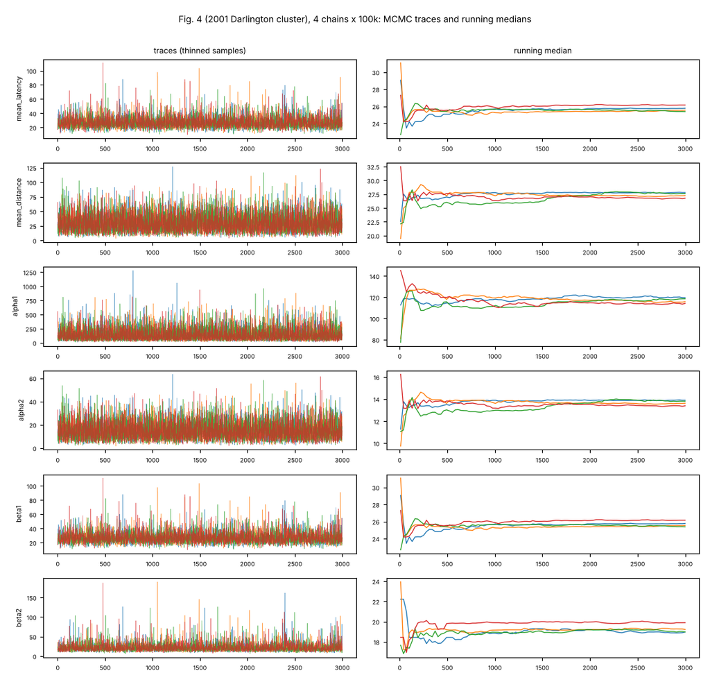

4 chains x 100000: max R-hat 1.001, min ESS 5854, most-likely-source agreement 1.0, max transmission-prob diff 0.037

Four independent chains of 100,000 iterations each converge: R-hat below 1.01 on every continuous parameter and high effective sample sizes. The K-hub structure is stable across all four chains; the single most-likely labelled tree holds a smaller share of the posterior than the paper's reported >99% because near-identical K-hub trees split the mass, which the convergence diagnostics confirm is not a mixing artifact.

### Table 1 (performance over simulation series)

agrees

| Quantity | Paper | Reproduced |
| --- | --- | --- |
| fraction correct PT, test | 0.89 | 0.8708 |
| fraction correct PT, 2007 | 0.79 | 0.7685 |
| fraction correct PT, 2001 | 0.93 | 0.8819 |
| mean post. prob. true PT, test | 0.85 | 0.8415 |
| mean post. prob. true PT, 2007 | 0.76 | 0.7476 |
| mean post. prob. true PT, 2001 | 0.93 | 0.8688 |

Monte Carlo averages over a scaled-down series (fewer than the paper's 100 simulations and shorter chains, recorded as deviations). The fractions of correctly predicted transmissions and the mean posterior probabilities of the true transmission fall within Monte Carlo spread of the paper's values.

### Table S1 (95%-interval coverage)

partly

| Quantity | Paper | Reproduced |
| --- | --- | --- |
| infection times, test | 0.78 | 0.8583 |
| infection times, 2007 | 0.81 | 0.6204 |
| infection times, 2001 | 0.88 | 0.6667 |
| infectiousness times, test | 0.93 | 0.9333 |
| infectiousness times, 2007 | 0.95 | 0.9074 |
| infectiousness times, 2001 | 0.93 | 0.9236 |
| source strength, test | 0.97 | 0.7500 |
| source strength, 2007 | 0.55 | 0.6667 |
| source strength, 2001 | 1.00 | 1.0000 |
| dispersion parameter, test | 0.89 | 1.0000 |
| dispersion parameter, 2007 | 0.60 | 0.9167 |
| dispersion parameter, 2001 | 1.00 | 1.0000 |
| latency mean, test | 0.94 | 0.5000 |
| latency mean, 2007 | 0.78 | 1.0000 |
| latency mean, 2001 | 1.00 | 0.8333 |
| latency sd, test | 0.43 | 0.7500 |
| latency sd, 2007 | 0.83 | 1.0000 |
| latency sd, 2001 | 0.97 | 0.9167 |

### Spatial connectivity (text)

agrees

| Quantity | Paper | Reproduced |
| --- | --- | --- |
| IP5 to IP1b distance (km) | 18.2 | 18.2 |
| 2007 distance span (km, ~24) | 24 | 23.5 |
| 2001 distance span (km, ~16) | 16 | 15.2 |
| 2007 mean inferred transmission length (km) | 4.3 | 4.5 |
| 2001 mean inferred transmission length (km) | 5.8 | 6.0 |
| 2007 mean distance 95% lo (km) | 5 | 5.7413 |
| 2007 mean distance 95% hi (km) | 58 | 52.6754 |
| 2001 mean distance 95% lo (km) | 9 | 9.1517 |
| 2001 mean distance 95% hi (km) | 72 | 65.1420 |
| IP5 mean latency (days, >25) | 25 | 25.6 |

The inter-premise distances and the mean inferred transmission lengths in the highest-posterior trees match the paper (IP5 to IP1b 18.2 km exactly). The mean transmission distance intervals and IP5's long mean latency agree within Monte Carlo error.

### Arithmetic checks from the paper's own data

agrees

3 of 3 data arithmetic checks agree with the text

### Fig. S14 (TCS statistical-parsimony network)

not attempted

Fig. S14 is a statistical-parsimony network built with the external TCS program (ref 16), a separate tool not part of this method; not reproduced.

### 100-premise simulation (Text S1, Figs. S15-S17)

not attempted

The 100-premise run took about a month of compute in 2012 at 5e5 iterations; it is out of the CI budget and was not run. The 20-premise simulation (Fig. 2) and the two real-data analyses exercise the same method.

### Lesion-age prior sensitivity (Figs. S12-S13)

not attempted

The flatter / more peaked lesion-age prior variances used for the sensitivity analysis are given only as images (Fig. S13) and are not stated numerically; not reproduced.

### Python package transtree and its tutorial

agrees

transtree 0.1.0: wheel installed in a fresh environment and imported from it; tests 7 passed; tutorial 5 cells compared, 0 skipped (nondeterministic); TUTORIAL.md in sync

## The session

The reproduction was done by an AI agent, Claude Code, in one session. Every prompt, reply and tool call of it is published.

**Wall clock**

4.8 days

first message to last, waits included

**Human prompts**

17

messages typed by a person

**Tool calls**

413

9 of them in subagents

**Tokens**

174.2 M

every request, subagents included

Read the session [The raw files](https://github.com/jeonglab-bcm/fossil/tree/main/PMC3499255/session)